# EstComp-Tarea10

Bruno C. Gonzalez

4/11/2019

## 10. Simulación muestra y bootstrap paramétrico

#### Simulación para calcular tamaños de muestra

Supongamos que queremos hacer una encuesta para estimar la proporción de hogares donde se consume refresco de manera regular, para ello se diseña un muestreo por conglomerados donde los conglomerados están dados por conjuntos de hoagres de tal manera que todos los conglomerados tienen el mismo número de hogares. La selección de la muestra se hará en dos etapas:

1. Seleccionamos $J$ conglomerados de manera aleatoria.
2. En cada conglomerado seleccionames $n/J$ hogares para entrevistar.

El estimador será simplemente el porcentaje de hogares del total de la muestra que consume refresco. Suponemos que la verdadera proporción es cercana a $0.50$ y que la media de la proporción de interés tiene una desviación estándar de $0.1$ a lo largo de los conglomerados .

1. Supongamos que la muestra total es de $n=1000$. ¿Cuál es la estimación del error estándar para la proporción estimada si $J=1,10,100,1000$?
2. El obejtivo es estimar la propoción que consume refresco en la población con un error estándar de a lo más $2\%$. ¿Que valores de $J$ y $n$ debemos elegir para cumplir el objetivo al menor costo?

Los costos del levantamiento son: + $50$ pesos por encuesta. + $500$ pesos por conglomerado

#### Bootstrap paramétrico

2. Sean $X_1,...,X_n \sim N(\mu, 1)$. Sea $\theta = e^{\mu}$, simula una muestra de $n=100$ observaciones usando $\mu=5$.
- Usa el método delta para estimar $\hat{se}$ de $\hat{\theta}$ y crea un intervalo del $95\%$ de confianza. Pista: $se(\hat{\mu}) = 1/\sqrt{n}$

Primero estimamos el *se*

```r
mu <- 5
theta <- exp(mu)
muestra <- rnorm(100, mu, 1)
mu_est <- (mean(muestra))
sd_est <- sd(muestra)

se_tetha <-  exp(mu_est)/sqrt(100)
sim_t <- rnorm(1000,exp(mu_est), se_tetha)
se_tetha
```

```
## [1] 15.28698
```

Con esta información construimos el intervalo de confianza.

```r
theta+se_tetha*c(qnorm(0.025), qnorm(0.975))
```

```
## [1] 118.4512 178.3751
```

- Repite el inciso anterior usando boostrap paramétrico.

Primero construimos la funcion para el bootstrap parametrica, usando los pámetros obtenidos anteriormente.

```r
theta_bootp <- function(){
  m <- rnorm(100, mu_est, sd_est)
  mu_boot <- mean(m)
  sd_boot <- sd(m)
  exp(mu_boot)
}
```

Con esta información podemos hacer la simulación y obtener el intervalo de confianza.

```r
sim_bootp <- rerun(1000, theta_bootp()) %>% flatten_dbl()
se_bootp <- sd(sim_bootp)
theta+se_bootp*c(qnorm(0.025), qnorm(0.975))
```

```
## [1] 119.1699 177.6564
```

- Finalmente usa bootstrap no paramétrico y compara tus respuestas.

Análogamente hacemos el bootstrap no parametrico.

```r
theta_bootnp <- function(){
  m <- sample(muestra, 100, replace = TRUE)
  mu_boot <- mean(m)
  sd_boot <- sd(m)
  exp(mu_boot)
}

sim_bootnp <- rerun(1000, theta_bootnp()) %>% flatten_dbl()
se_bootnp <- sd(sim_bootnp)
theta+se_bootnp*c(qnorm(0.025), qnorm(0.975))
```

```
## [1] 119.2206 177.6057
```

- Realiza un histograma de replicaciones bootstrap para cada método, estas son estimaciones de la distribución de $\hat{\theta}$. El método delta también nos da una aproximación a esta distribución: $Normal(\hat{\theta},\hat{se}^2)$. Comparalos con la verdadera distribución de $\hat{\theta}$ (que puedes obtener vía simulación). ¿Cuál es la aproximación más cercana a la verdadera distribución?

Primero hacemos la simulación de la distribución real.

```r
sim <- function(){
  m <- rnorm(100, mu, 1)
  exp(mean(m))
}

simn <- rerun(1000, sim()) %>% flatten_dbl()
```

Con estos datos y con los obtenidos anteriormente podemos hacer los histogramas.

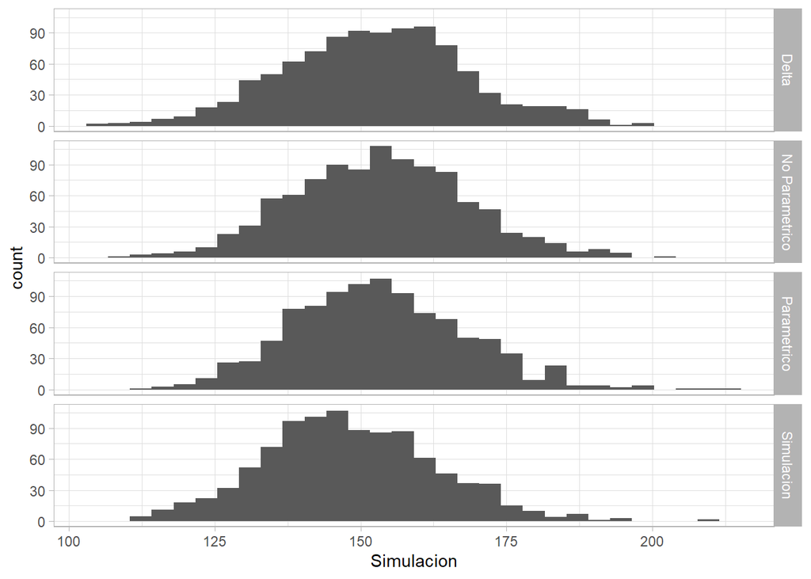

```r
df <- tibble(Simulacion = sim_bootp, Metodo = 'Parametrico') %>%
  rbind(tibble(Simulacion = sim_bootnp, Metodo = 'No Parametrico')) %>%
  rbind(tibble(Simulacion = sim_t, Metodo = 'Delta')) %>%
  rbind(tibble(Simulacion = simn, Metodo = 'Simulacion'))

ggplot(df) +
  geom_histogram(aes(Simulacion)) +
  facet_grid(Metodo~.) +
  theme_light()
```

El metodo que más se aproxima a la simulación es el bootstrap parametrico, esto tiene sentido ya que este metodo aprovecha la información parametrica disponible.